# K-Means Clustering

Analytics for Financial Data Science

Author

Mike Aguilar

# Learning Objectives

By the end of this lesson, students should be able to:

- Explain how K-means assigns observations to clusters and updates cluster centroids.
- Prepare a cross-sectional feature set for clustering, including checks for missing values, duplicate keys, unstable growth rates, scale differences, and influential observations.
- Explain why feature selection, standardization, random starting values, and the choice of $K$ can change the resulting partition.
- Use the elbow, gap-statistic, and silhouette approaches as complementary evidence when choosing $K$.
- Interpret clusters economically and describe how a commercial bank might use—and validate—the resulting segmentation.

# Housekeeping

```r
cat("\014")  # clear the console when run interactively
```

```r
rm(list = ls())  # begin from a clean workspace

if (!requireNamespace("here", quietly = TRUE)) {
  stop("Install the 'here' package before rendering this document.")
}

suppressPackageStartupMessages(library(here))
source(here("Supporting", "ProjectSetup.R"))
```

# Background

- You are a data scientist at a large commercial bank.
- The bank lends to businesses in many industries.
- The CEO wants to group industries with similar operating characteristics so that the bank can design lending policies, monitoring rules, and stress tests for economically similar groups.
- We will use K-means as an unsupervised clustering algorithm. There is no target variable and no preassigned “correct” cluster for an industry.

Q: What is the unit that we ultimately want to cluster?

A: Industries. The features used to compare those industries will be financial levels and growth rates.

# Data

## Acquisition

Task: Load the data dictionary from the `Data_Dictionary` sheet of `industry_fundamentals.xlsx`.

```r
data_dictionary <- readxl::read_excel(
  here("Data", "industry_fundamentals.xlsx"),
  sheet = "Data_Dictionary"
)

data_dictionary
```

```
# A tibble: 5 × 6
  variable       description                         units type  category source
  <chr>          <chr>                               <chr> <chr> <chr>    <chr>
1 Industry       Industry identifier                 Iden… Char… Identif… Simul…
2 Year           Observation year within the two-ye… Year… Inte… Time     Simul…
3 Revenue        Industry revenue for the observati… Simu… Nume… Financi… Simul…
4 Operating_Cost Industry operating cost for the ob… Simu… Nume… Financi… Simul…
5 Profit         Industry profit, calculated as Rev… Simu… Nume… Financi… Simul…
```

Q: Before analyzing the observations, how do you expect industries to group based on size, growth, and profitability?

A: Student expectations will vary. Record the hypotheses now so that they can be compared with the data-driven clusters later.

Task: Load the `Data` sheet and call the object `industry_fundamentals`.

```r
industry_fundamentals <- readxl::read_excel(
  here("Data", "industry_fundamentals.xlsx"),
  sheet = "Data"
)

dplyr::glimpse(industry_fundamentals)
```

```
Rows: 100
Columns: 5
$ Industry       <chr> "Industry01", "Industry01", "Industry02", "Industry02",…
$ Year           <dbl> 1, 2, 1, 2, 1, 2, 1, 2, 1, 2, 1, 2, 1, 2, 1, 2, 1, 2, 1…
$ Revenue        <dbl> 1009.16477, 982.93435, 380.18700, 443.82712, 282.50265,…
$ Operating_Cost <dbl> 625.958473, 600.652092, 326.041719, 402.160118, 162.880…
$ Profit         <dbl> 383.206296, 382.282254, 54.145280, 41.667004, 119.62262…
```

## Validate the Data Structure

A clustering algorithm will return an answer even when the input has structural problems. We therefore verify the unit of observation and the variables before engineering features.

Task: Display the fields in the dataset.

```r
names(industry_fundamentals)
```

```
[1] "Industry"       "Year"           "Revenue"        "Operating_Cost"
[5] "Profit"
```

Task: Count rows, distinct industries, and distinct years.

```r
industry_fundamentals %>%
  summarise(
    rows = n(),
    industries = n_distinct(Industry),
    years = n_distinct(Year)
  )
```

```
# A tibble: 1 × 3
   rows industries years
  <int>      <int> <int>
1   100         50     2
```

Q: What is the unit of observation in the source data: industry, year, revenue, or something else?

A: An industry-year. Each row describes one industry in one year.

Task: Verify that each industry-year key is unique.

```r
duplicate_keys <- industry_fundamentals %>%
  dplyr::count(Industry, Year, name = "rows_per_key") %>%
  filter(rows_per_key > 1)

duplicate_keys
```

```
# A tibble: 0 × 3
# ℹ 3 variables: Industry <chr>, Year <dbl>, rows_per_key <int>
```

```r
stopifnot(nrow(duplicate_keys) == 0)
```

Task: Verify that every industry appears in every year represented in the data.

```r
analysis_years <- sort(unique(industry_fundamentals$Year))
stopifnot(length(analysis_years) == 2)

year_1 <- analysis_years[1]
year_2 <- analysis_years[2]

incomplete_industries <- industry_fundamentals %>%
  dplyr::count(Industry, name = "observed_years") %>%
  filter(observed_years != length(analysis_years))

incomplete_industries
```

```
# A tibble: 0 × 2
# ℹ 2 variables: Industry <chr>, observed_years <int>
```

```r
stopifnot(nrow(incomplete_industries) == 0)
```

## Cleaning and Accounting Checks

Task: Count missing values by field

```r
missing_by_field <- industry_fundamentals %>%
  summarise(across(everything(), ~ sum(is.na(.x)))) %>%
  pivot_longer(
    cols = everything(),
    names_to = "field",
    values_to = "missing_values"
  )

missing_by_field
```

```
# A tibble: 5 × 2
  field          missing_values
  <chr>                   <int>
1 Industry                    0
2 Year                        0
3 Revenue                     0
4 Operating_Cost              0
5 Profit                      0
```

```r
stopifnot(sum(missing_by_field$missing_values) == 0)
```

Task: Verify the accounting identity $\text{Profit}=\text{Revenue}-\text{Operating Cost}$.

```r
accounting_check <- industry_fundamentals %>%
  summarise(
    maximum_absolute_error = max(
      abs(Profit - (Revenue - Operating_Cost)),
      na.rm = TRUE
    )
  )

accounting_check
```

```
# A tibble: 1 × 1
  maximum_absolute_error
                   <dbl>
1               7.28e-12
```

Q: Why does this identity matter for clustering?

A: Profit does not add a new independent dimension when it is exactly Revenue minus Operating Cost. Adding it can nevertheless change K-means because it adds another axis to the distance calculation and therefore changes the weighting of the feature space. We will demonstrate that distinction later.

## Engineering Growth Rates

Task: Compute simple growth rates for each industry from the first year to the second year.

```r
growth_rates <- industry_fundamentals %>%
  arrange(Industry, Year) %>%
  group_by(Industry) %>%
  summarise(
    Revenue_Year1 = first(Revenue),
    Revenue_Year2 = last(Revenue),
    Operating_Cost_Year1 = first(Operating_Cost),
    Operating_Cost_Year2 = last(Operating_Cost),
    Profit_Year1 = first(Profit),
    Profit_Year2 = last(Profit),
    .groups = "drop"
  ) %>%
  mutate(
    Revenue_Growth = Revenue_Year2 / Revenue_Year1 - 1,
    Cost_Growth = Operating_Cost_Year2 / Operating_Cost_Year1 - 1,
    Profit_Growth = Profit_Year2 / Profit_Year1 - 1
  )

head(growth_rates)
```

```
# A tibble: 6 × 10
  Industry Revenue_Year1 Revenue_Year2 Operating_Cost_Year1 Operating_Cost_Year2
  <chr>            <dbl>         <dbl>                <dbl>                <dbl>
1 Industr…         1009.          983.                 626.                 601.
2 Industr…          380.          444.                 326.                 402.
3 Industr…          283.          290.                 163.                 168.
4 Industr…          356.          370.                 218.                 230.
5 Industr…          167.          159.                 112.                 106.
6 Industr…          260.          312.                 218.                 281.
# ℹ 5 more variables: Profit_Year1 <dbl>, Profit_Year2 <dbl>,
#   Revenue_Growth <dbl>, Cost_Growth <dbl>, Profit_Growth <dbl>
```

Task: Inspect the Year 1 denominators used to calculate growth.

```r
growth_denominator_check <- growth_rates %>%
  summarise(
    minimum_revenue_base = min(Revenue_Year1),
    minimum_cost_base = min(Operating_Cost_Year1),
    minimum_absolute_profit_base = min(abs(Profit_Year1)),
    nonpositive_profit_bases = sum(Profit_Year1 <= 0)
  )

growth_denominator_check
```

```
# A tibble: 1 × 4
  minimum_revenue_base minimum_cost_base minimum_absolute_profit_base
                 <dbl>             <dbl>                        <dbl>
1                 9.70              9.21                        0.485
# ℹ 1 more variable: nonpositive_profit_bases <int>
```

```r
stopifnot(
  all(growth_rates$Revenue_Year1 != 0),
  all(growth_rates$Operating_Cost_Year1 != 0),
  all(growth_rates$Profit_Year1 != 0)
)
```

Q: Why should Profit Growth be interpreted more cautiously than Revenue Growth or Cost Growth?

A:

## Construct the Analysis Samples

K-means is sensitive to the sample used to estimate means, standard deviations, and centroids. We will standardize each feature within the cross-sectional sample actually being clustered.

Task: Construct full Year 1 levels sample and full industry growth sample, then create standardized versions of each.

```r
z_score <- function(x) {
  as.numeric(scale(x))
}

year1 <- industry_fundamentals %>%
  filter(Year == year_1)

year1_std_full <- year1 %>%
  mutate(
    Revenue_z = z_score(Revenue),
    Operating_Cost_z = z_score(Operating_Cost),
    Profit_z = z_score(Profit)
  )

growth_rates_std_full <- growth_rates %>%
  mutate(
    Revenue_Growth_z = z_score(Revenue_Growth),
    Cost_Growth_z = z_score(Cost_Growth),
    Profit_Growth_z = z_score(Profit_Growth)
  )
```

# Exploratory Data Analysis

We will focus on exploratory analysis that affects the clustering choices made later.

## Levels and Growth Distributions

Task: For Year 1, create side-by-side violin plots of Revenue, Operating Cost, and Profit in their raw dollar units.

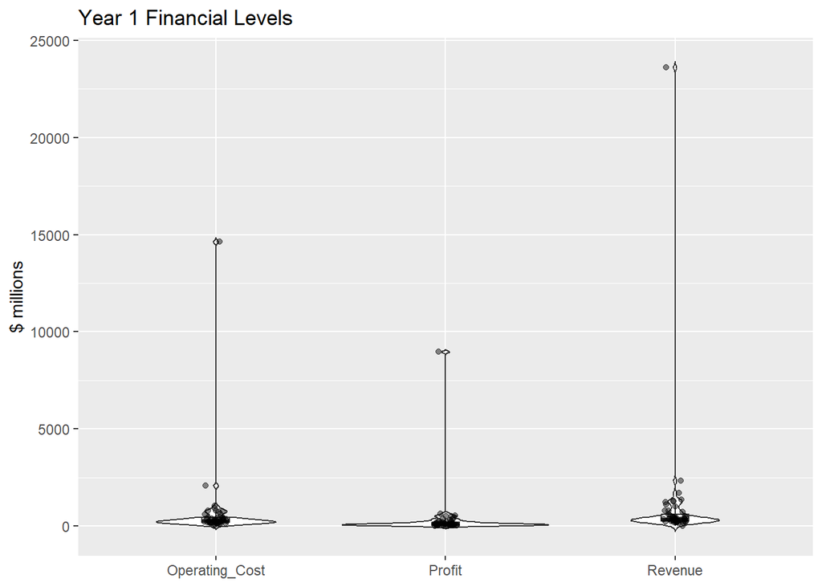

```r
year1_long <- year1 %>%
  pivot_longer(
    cols = c(Revenue, Operating_Cost, Profit),
    names_to = "metric",
    values_to = "value"
  )

ggplot(year1_long, aes(x = metric, y = value)) +
  geom_violin(trim = FALSE) +
  geom_boxplot(width = 0.12, outlier.shape = NA, alpha = 0.25) +
  geom_jitter(width = 0.05, alpha = 0.45) +
  labs(
    title = "Year 1 Financial Levels",
    x = NULL,
    y = "$ millions"
  )
```

Task: Create side-by-side violin plots of Revenue Growth, Cost Growth, and Profit Growth.

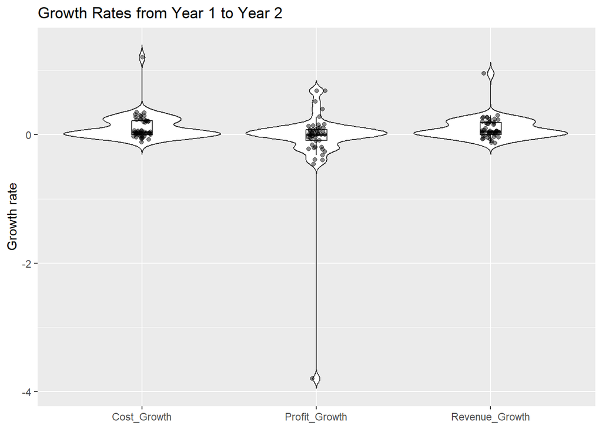

```r
growth_long <- growth_rates %>%
  pivot_longer(
    cols = c(Revenue_Growth, Cost_Growth, Profit_Growth),
    names_to = "metric",
    values_to = "value"
  )

ggplot(growth_long, aes(x = metric, y = value)) +
  geom_violin(trim = FALSE) +
  geom_boxplot(width = 0.12, outlier.shape = NA, alpha = 0.25) +
  geom_jitter(width = 0.05, alpha = 0.45) +
  labs(
    title = "Growth Rates from Year 1 to Year 2",
    x = NULL,
    y = "Growth rate"
  )
```

## Identify Influential Observations

An observation can be unusual in the levels feature space but ordinary in the growth feature space, or vice versa.

Task: Identify observations at least three standard deviations from the mean in either feature space.

```r
level_outlier_flags <- year1_std_full %>%
  select(Industry, Revenue_z, Operating_Cost_z, Profit_z) %>%
  pivot_longer(
    cols = -Industry,
    names_to = "metric",
    values_to = "z_score"
  ) %>%
  filter(abs(z_score) >= 3) %>%
  arrange(desc(abs(z_score)))

growth_outlier_flags <- growth_rates_std_full %>%
  select(Industry, Revenue_Growth_z, Cost_Growth_z, Profit_Growth_z) %>%
  pivot_longer(
    cols = -Industry,
    names_to = "metric",
    values_to = "z_score"
  ) %>%
  filter(abs(z_score) >= 3) %>%
  arrange(desc(abs(z_score)))

level_outlier_flags
```

```
# A tibble: 3 × 3
  Industry   metric           z_score
  <chr>      <chr>              <dbl>
1 Industry32 Profit_z            6.88
2 Industry32 Revenue_z           6.87
3 Industry32 Operating_Cost_z    6.84
```

```r
growth_outlier_flags
```

```
# A tibble: 3 × 3
  Industry   metric           z_score
  <chr>      <chr>              <dbl>
1 Industry07 Profit_Growth_z    -6.38
2 Industry07 Cost_Growth_z       5.39
3 Industry07 Revenue_Growth_z    5.06
```

Task: Inspect the complete records for the two influential industries identified by the plots and z-scores.

```r
year1 %>%
  filter(Industry == "Industry32")
```

```
# A tibble: 1 × 5
  Industry    Year Revenue Operating_Cost Profit
  <chr>      <dbl>   <dbl>          <dbl>  <dbl>
1 Industry32     1  23592.         14627.  8965.
```

```r
growth_rates %>%
  filter(Industry == "Industry07")
```

```
# A tibble: 1 × 10
  Industry Revenue_Year1 Revenue_Year2 Operating_Cost_Year1 Operating_Cost_Year2
  <chr>            <dbl>         <dbl>                <dbl>                <dbl>
1 Industr…          9.70          18.9                 9.21                 20.3
# ℹ 5 more variables: Profit_Year1 <dbl>, Profit_Year2 <dbl>,
#   Revenue_Growth <dbl>, Cost_Growth <dbl>, Profit_Growth <dbl>
```

Q: What do the plots and diagnostic tables suggest? Are we looking at one outlier or more than one?

A:

- There are two different influential observations in two different feature spaces.
- `Industry32` is extremely large in Revenue, Operating Cost, and Profit, but its growth rates are ordinary. It is unusual in size, not necessarily in operating regime.
- `Industry07` has an extreme Profit Growth observation driven by unusually large Revenue and Cost Growth, with costs outpacing revenue. Its dollar levels are not unusually large.
- “Unusual” does not mean “incorrect.” We will retain the full datasets, exclude the influential observation from the corresponding main analysis to reveal the broader structure, and then add each observation back in a formal sensitivity analysis.

Task: Build a levels sample excluding `Industry32` and a growth-rate sample excluding `Industry07`. Re-standardize within each trimmed sample.

```r
year1_trim <- year1 %>%
  filter(Industry != "Industry32") %>%
  mutate(
    Revenue_z = z_score(Revenue),
    Operating_Cost_z = z_score(Operating_Cost),
    Profit_z = z_score(Profit)
  )

growth_rates_trim <- growth_rates %>%
  filter(Industry != "Industry07") %>%
  mutate(
    Revenue_Growth_z = z_score(Revenue_Growth),
    Cost_Growth_z = z_score(Cost_Growth),
    Profit_Growth_z = z_score(Profit_Growth)
  )

nrow(year1_trim)
```

```
[1] 49
```

```r
nrow(growth_rates_trim)
```

```
[1] 49
```

## Correlation and Outlier Influence

Correlation is unchanged by positive linear rescaling, so it is clearest to compute these correlations in the original growth-rate units.

```r
correlation_long <- function(correlation_matrix) {
  as.data.frame(as.table(correlation_matrix)) %>%
    as_tibble() %>%
    rename(
      variable_1 = Var1,
      variable_2 = Var2,
      correlation = Freq
    )
}

plot_correlation <- function(correlation_matrix, plot_title) {
  correlation_long(correlation_matrix) %>%
    ggplot(aes(variable_1, variable_2, fill = correlation)) +
    geom_tile() +
    scale_fill_gradient2(
      low = "blue",
      high = "red",
      mid = "white",
      midpoint = 0,
      limits = c(-1, 1),
      name = "Correlation"
    ) +
    labs(title = plot_title, x = NULL, y = NULL) +
    theme_minimal()
}
```

Task: Compute and visualize correlations using all industries.

```r
growth_cor_full <- growth_rates %>%
  select(Revenue_Growth, Cost_Growth, Profit_Growth) %>%
  cor(use = "complete.obs")

growth_cor_full
```

```
               Revenue_Growth Cost_Growth Profit_Growth
Revenue_Growth      1.0000000   0.9739477    -0.5756940
Cost_Growth         0.9739477   1.0000000    -0.6976971
Profit_Growth      -0.5756940  -0.6976971     1.0000000
```

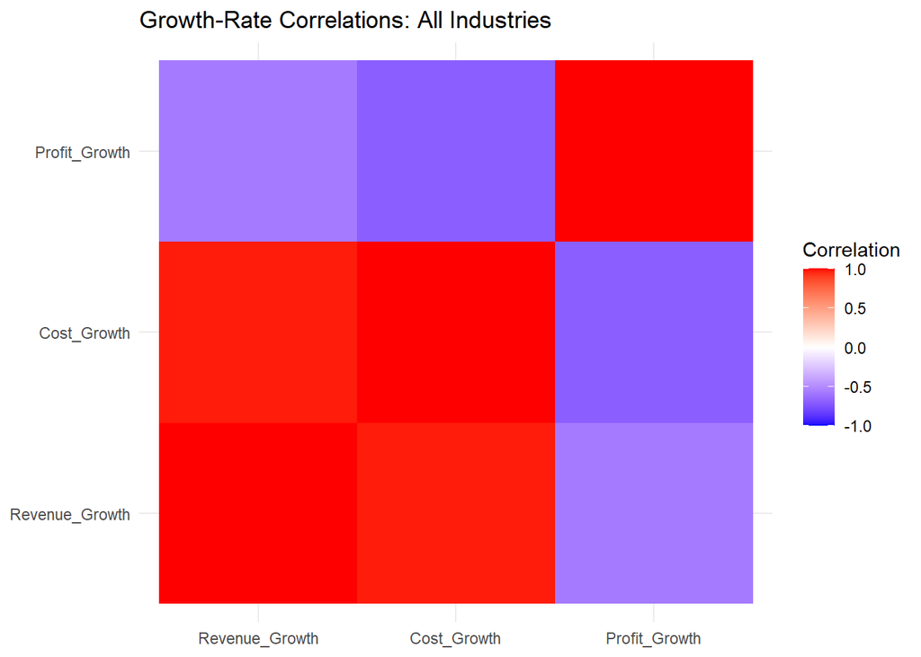

```r
plot_correlation(growth_cor_full, "Growth-Rate Correlations: All Industries")
```

Task: Recompute and visualize the correlations after excluding `Industry07`.

```r
growth_cor_trim <- growth_rates_trim %>%
  select(Revenue_Growth, Cost_Growth, Profit_Growth) %>%
  cor(use = "complete.obs")

growth_cor_trim
```

```
               Revenue_Growth Cost_Growth Profit_Growth
Revenue_Growth      1.0000000  0.94521032    0.36672672
Cost_Growth         0.9452103  1.00000000    0.07564675
Profit_Growth       0.3667267  0.07564675    1.00000000
```

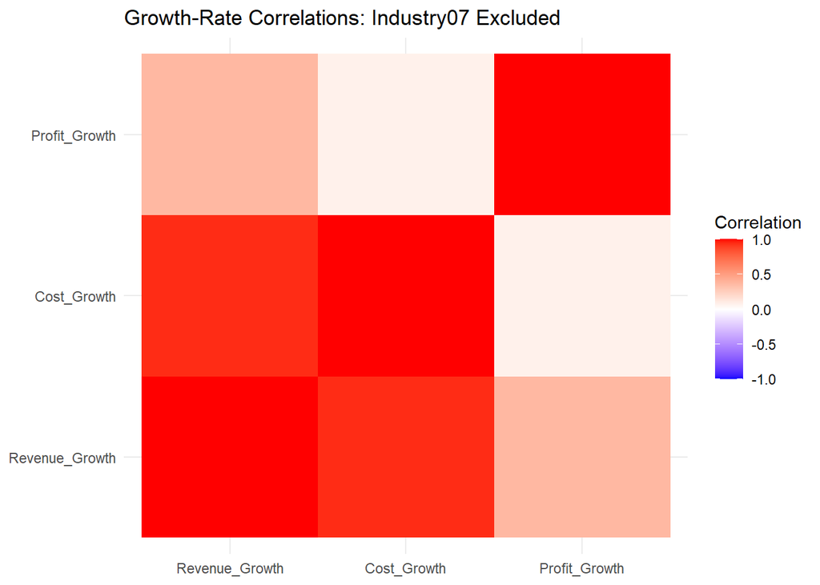

```r
plot_correlation(growth_cor_trim, "Growth-Rate Correlations: Industry07 Excluded")
```

Q: How does removing `Industry07` change the correlation structure?

A:

- Revenue Growth and Cost Growth remain strongly positively correlated: $r=$ 0.97 with the observation included and $r=$ 0.95 after it is excluded.
- The relationship between Profit Growth and Revenue Growth changes from $r=$ -0.58 to $r=$ 0.37.
- The relationship between Profit Growth and Cost Growth changes from $r=$ -0.7 to $r=$ 0.08.
- The broader lesson is that one influential observation can materially alter a statistic that will later shape the geometry and interpretation of a clustering analysis.

# K-Means

## Intuition and Algorithm

Q: How does K-means cluster observations?

A:

- K-means groups observations that are close to one another in the selected feature space.
- Closeness is usually measured with Euclidean distance.
- The analyst chooses the number of clusters, $K$, in advance.
- The algorithm selects $K$ initial cluster centers, called centroids.
- Each observation is assigned to its nearest centroid.
- Each centroid is recomputed as the mean of the observations assigned to that cluster.
- Assignment and centroid updates repeat until no further reassignment improves the objective, or until an implementation-specific stopping rule is reached.
- The final solution minimizes the total squared distance from observations to their assigned centroid, subject to the local solution reached from the starting values.

Q: Does K-means cluster observations or variables?

A: Observations. The variables define the coordinates used to measure distance between those observations. Here, the observations are industries and the variables are financial growth rates or levels.

## A Basic Fit

For the basic mechanics, use the trimmed Revenue Growth and Cost Growth sample. We set `nstart = 1` here so that the relationship between random initialization and reproducibility remains visible.

Task: Fit K-means with $K=3$.

```r
basic_features <- growth_rates_trim %>%
  select(Revenue_Growth, Cost_Growth)

set.seed(1234)
basic_kmeans <- kmeans(
  basic_features,
  centers = 3,
  nstart = 1
)
```

Task: Display each industry with its assigned cluster.

```r
basic_assignments <- tibble(
  Industry = growth_rates_trim$Industry,
  cluster = basic_kmeans$cluster
)

basic_assignments
```

```
# A tibble: 49 × 2
   Industry   cluster
   <chr>        <int>
 1 Industry01       1
 2 Industry02       2
 3 Industry03       3
 4 Industry04       3
 5 Industry05       1
 6 Industry06       2
 7 Industry08       3
 8 Industry09       1
 9 Industry10       2
10 Industry11       3
# ℹ 39 more rows
```

Q: How should the cluster vector be interpreted?

A: Each industry receives one cluster label. The numbers 1, 2, and 3 are arbitrary identifiers, not rankings. “Cluster 3” is not intrinsically larger, riskier, or better than “Cluster 1.” Interpret a cluster only after examining its centroid and members.

Task: Display the cluster centroids.

```r
basic_centers <- basic_kmeans$centers %>%
  as.data.frame() %>%
  tibble::rownames_to_column("cluster") %>%
  as_tibble()

basic_centers
```

```
# A tibble: 3 × 3
  cluster Revenue_Growth Cost_Growth
  <chr>            <dbl>       <dbl>
1 1              -0.0653     -0.0448
2 2               0.218       0.253
3 3               0.0364      0.0290
```

Q: How should the centroids be interpreted?

A: Each row contains the mean Revenue Growth and mean Cost Growth of the industries assigned to that cluster. Because the fit used raw growth rates, the centroid values are also in raw growth-rate units.

## The K-Means Objective and R Output

Define:

- $\mathbf{x}_i$: the $p \times 1$ feature vector for observation $i$.
- $\bar{\mathbf{x}}$: the overall sample mean vector.
- $\boldsymbol{\mu}_k$: the centroid of cluster $k$.
- $C_k$: the set of observations assigned to cluster $k$.
- $n_k$: the number of observations in cluster $k$.

The main quantities returned by `kmeans()` are:

### Total Sum of Squares: `totss`

$$\mathrm{TSS}
=
\sum_{i=1}^{N}
\left\|\mathbf{x}_i-\bar{\mathbf{x}}\right\|^2.$$

This measures total dispersion around the overall mean before using the cluster assignments.

### Within-Cluster Sum of Squares: `withinss`

For cluster $k$,

$$\mathrm{WithinSS}_k
=
\sum_{i \in C_k}
\left\|\mathbf{x}_i-\boldsymbol{\mu}_k\right\|^2.$$

This measures the total squared distance of the observations in cluster $k$ from that cluster’s centroid.

### Total Within-Cluster Sum of Squares: `tot.withinss`

$$\mathrm{Total\ WithinSS}
=
\sum_{k=1}^{K}\mathrm{WithinSS}_k.$$

This is the objective that K-means attempts to minimize.

### Between-Cluster Sum of Squares: `betweenss`

$$\mathrm{BetweenSS}
=
\sum_{k=1}^{K}
n_k
\left\|\boldsymbol{\mu}_k-\bar{\mathbf{x}}\right\|^2.$$

This measures how far the cluster centroids are from the overall mean, weighted by cluster size.

The decomposition is

$$\boxed{
\mathrm{TSS}
=
\mathrm{Total\ WithinSS}
+
\mathrm{BetweenSS}
}.$$

Task: Display the fit statistics and verify the decomposition.

```r
basic_fit_statistics <- tibble(
  totss = basic_kmeans$totss,
  tot_withinss = basic_kmeans$tot.withinss,
  betweenss = basic_kmeans$betweenss,
  decomposition_error = basic_kmeans$totss -
    basic_kmeans$tot.withinss -
    basic_kmeans$betweenss,
  between_share = basic_kmeans$betweenss / basic_kmeans$totss
)

basic_fit_statistics
```

```
# A tibble: 1 × 5
  totss tot_withinss betweenss decomposition_error between_share
  <dbl>        <dbl>     <dbl>               <dbl>         <dbl>
1  1.44        0.118      1.32                   0         0.918
```

Task: Compare cluster size, `withinss`, and `withinss` per observation.

```r
basic_cluster_statistics <- tibble(
  cluster = seq_along(basic_kmeans$size),
  size = basic_kmeans$size,
  withinss = basic_kmeans$withinss,
  withinss_per_observation = basic_kmeans$withinss / basic_kmeans$size
)

basic_cluster_statistics
```

```
# A tibble: 3 × 4
  cluster  size withinss withinss_per_observation
    <int> <int>    <dbl>                    <dbl>
1       1    11   0.0261                 0.00237
2       2    17   0.0726                 0.00427
3       3    21   0.0192                 0.000914
```

Q: Are these sums of squares best interpreted in relative or absolute terms?

A: Usually relative.

- `totss` is fixed only when the observations, features, units, and scaling are fixed.
- `tot.withinss` can be compared across alternative fits on the same feature matrix, but it falls mechanically as $K$ increases and therefore cannot choose $K$ by itself.
- `betweenss / totss` describes how much total dispersion is represented between the fitted clusters, but it is not a universal goodness-of-fit threshold.
- A large cluster often has a large `withinss` simply because it contains more observations. `withinss / size` is more informative when comparing average squared dispersion across clusters, although it still depends on the features and their scaling.

## Random Initialization and `set.seed()`

K-means can converge to different local solutions from different random starting centroids. In addition, cluster numbers can be permuted even when the underlying partition is the same.

Task: Run the same one-start specification twice without resetting the seed, then compare both the objective value and the partition. Also compute the “adjustedRandIndex”.

Note: The Adjusted Rand Index (ARI) measures how similar two cluster assignments are while ignoring the arbitrary numeric cluster labels, with 1 indicating identical clustering and values near 0 indicating agreement no better than chance.

```r
set.seed(9001)
km_random_1 <- kmeans(basic_features, centers = 3, nstart = 1)
km_random_2 <- kmeans(basic_features, centers = 3, nstart = 1)

c(
  run_1_tot_withinss = km_random_1$tot.withinss,
  run_2_tot_withinss = km_random_2$tot.withinss
)
```

```
run_1_tot_withinss run_2_tot_withinss
         0.1178920          0.1951997
```

```r
mclust::adjustedRandIndex(
  km_random_1$cluster,
  km_random_2$cluster
)
```

```
[1] 0.4807939
```

Q: Why might the two results differ even though the model specification did not change?

A: Each call can begin from different random centroids. A different objective value indicates a substantively different local solution. A high Adjusted Rand Index with different-looking numeric labels may instead reflect simple label switching.

Task: Reset to the same seed before each run and verify exact reproducibility.

```r
set.seed(1234)
km_seed_1 <- kmeans(basic_features, centers = 3, nstart = 1)

set.seed(1234)
km_seed_2 <- kmeans(basic_features, centers = 3, nstart = 1)

identical(km_seed_1$cluster, km_seed_2$cluster)
```

```
[1] TRUE
```

```r
identical(km_seed_1$centers, km_seed_2$centers)
```

```
[1] TRUE
```

Q: What does `set.seed()` accomplish?

A: `set.seed()` makes the random initialization reproducible. It does not guarantee that a one-start fit is the best available solution. We address that issue with `nstart` in the sensitivity section.

# Why Feature Redundancy Matters

Q: Suppose we cluster standardized Year 1 Revenue and Operating Cost. What do you expect to happen if standardized Profit is added?

A: Because Profit is exactly Revenue minus Operating Cost, it adds no new independent accounting information. However, adding Profit adds another term to Euclidean distance and therefore reweights the geometry. We expect high—but not necessarily perfect—agreement.

Task: Verify the accounting identity in the trimmed Year 1 sample.

```r
year1_trim %>%
  summarise(
    maximum_absolute_error = max(
      abs(Profit - (Revenue - Operating_Cost))
    )
  )
```

```
# A tibble: 1 × 1
  maximum_absolute_error
                   <dbl>
1               5.12e-13
```

Task: Fit $K=2$ using standardized Revenue and Operating Cost.

```r
set.seed(1234)
km_2feat <- kmeans(
  year1_trim %>% select(Revenue_z, Operating_Cost_z),
  centers = 2,
  nstart = 20
)
```

Task: Fit $K=2$ using standardized Revenue, Operating Cost, and Profit.

```r
set.seed(1234)
km_all3 <- kmeans(
  year1_trim %>% select(Revenue_z, Operating_Cost_z, Profit_z),
  centers = 2,
  nstart = 20
)
```

Task: Compute cluster profiles for both specifications.

```r
year1_feature_comparison <- year1_trim %>%
  mutate(
    cluster_2feat = km_2feat$cluster,
    cluster_all3 = km_all3$cluster
  )

year1_feature_comparison %>%
  group_by(cluster_2feat) %>%
  summarise(
    across(c(Revenue, Operating_Cost, Profit), mean),
    n = n(),
    .groups = "drop"
  )
```

```
# A tibble: 2 × 5
  cluster_2feat Revenue Operating_Cost Profit     n
          <int>   <dbl>          <dbl>  <dbl> <int>
1             1   1419.           971.   448.     8
2             2    363.           260.   102.    41
```

```r
year1_feature_comparison %>%
  group_by(cluster_all3) %>%
  summarise(
    across(c(Revenue, Operating_Cost, Profit), mean),
    n = n(),
    .groups = "drop"
  )
```

```
# A tibble: 2 × 5
  cluster_all3 Revenue Operating_Cost Profit     n
         <int>   <dbl>          <dbl>  <dbl> <int>
1            1   1351.           914.  438.      9
2            2    352.           255.   96.2    40
```

Cluster labels are arbitrary, so they must be aligned before identifying observations that “switch” numeric labels. The helper below is specific to a two-cluster comparison.

```r
align_two_cluster_labels <- function(reference, candidate) {
  same_label_agreement <- sum(reference == candidate)
  swapped_label_agreement <- sum(reference == (3 - candidate))

  if (swapped_label_agreement > same_label_agreement) {
    3 - candidate
  } else {
    candidate
  }
}

year1_feature_comparison <- year1_feature_comparison %>%
  mutate(
    cluster_2feat_aligned = align_two_cluster_labels(
      reference = cluster_all3,
      candidate = cluster_2feat
    )
  )

feature_crosstab <- table(
  All3 = year1_feature_comparison$cluster_all3,
  TwoFeat = year1_feature_comparison$cluster_2feat
)

feature_switches <- year1_feature_comparison %>%
  filter(cluster_all3 != cluster_2feat_aligned) %>%
  select(Industry, cluster_all3, cluster_2feat_aligned)

feature_ari <- mclust::adjustedRandIndex(
  year1_feature_comparison$cluster_all3,
  year1_feature_comparison$cluster_2feat
)

feature_switch_text <- if (nrow(feature_switches) == 0) {
  "none"
} else {
  paste(feature_switches$Industry, collapse = ", ")
}

feature_crosstab
```

```
    TwoFeat
All3  1  2
   1  8  1
   2  0 40
```

```r
feature_switches
```

```
# A tibble: 1 × 3
  Industry   cluster_all3 cluster_2feat_aligned
  <chr>             <int>                 <int>
1 Industry44            1                     2
```

```r
feature_ari
```

```
[1] 0.9014745
```

Q: How much did cluster membership change after Profit was added?

A: The Adjusted Rand Index is 0.9, where 1 indicates identical partitions and 0 is the agreement expected by chance under the index’s adjustment. After aligning the arbitrary numeric labels, 1 industries changed assignment: Industry44.

Q: If Profit adds no new independent information, why can it change the clusters?

A: Standardizing each field separately produces three axes with unit variance. The all-three-feature objective includes a Profit term,

$$d^2
=
(\Delta z_{Revenue})^2
+
(\Delta z_{Cost})^2
+
(\Delta z_{Profit})^2,$$

whereas the two-feature objective omits the final term. The data still lie on a two-dimensional accounting plane, but distances along directions associated with Profit receive additional weight. A borderline observation can therefore move to another nearest centroid.

# Why Standardization Matters

K-means is not invariant to rescaling. Multiplying one feature by 100 multiplies its contribution to squared Euclidean distance by $100^2$.

## Raw Versus Standardized Features in This Dataset

Task: Compare $K=2$ fits for raw and standardized Year 1 levels.

```r
set.seed(4821)
km_raw_levels <- kmeans(
  year1_trim %>% select(Revenue, Operating_Cost),
  centers = 2,
  nstart = 20
)

set.seed(4821)
km_std_levels <- kmeans(
  year1_trim %>% select(Revenue_z, Operating_Cost_z),
  centers = 2,
  nstart = 20
)
```

Task: Compare $K=2$ fits for raw and standardized growth rates.

```r
set.seed(4821)
km_raw_growth <- kmeans(
  growth_rates_trim %>% select(Revenue_Growth, Cost_Growth),
  centers = 2,
  nstart = 20
)

set.seed(4821)
km_std_growth <- kmeans(
  growth_rates_trim %>% select(Revenue_Growth_z, Cost_Growth_z),
  centers = 2,
  nstart = 20
)
```

Task: Quantify agreement and compare the raw feature standard deviations.

```r
scale_agreement <- tibble(
  comparison = c("Year 1 levels", "Growth rates"),
  adjusted_rand_index = c(
    mclust::adjustedRandIndex(
      km_raw_levels$cluster,
      km_std_levels$cluster
    ),
    mclust::adjustedRandIndex(
      km_raw_growth$cluster,
      km_std_growth$cluster
    )
  )
)

feature_scale_summary <- bind_rows(
  year1_trim %>%
    summarise(
      Revenue = sd(Revenue),
      Operating_Cost = sd(Operating_Cost)
    ) %>%
    pivot_longer(everything(), names_to = "feature", values_to = "standard_deviation") %>%
    mutate(sample = "Year 1 levels"),
  growth_rates_trim %>%
    summarise(
      Revenue_Growth = sd(Revenue_Growth),
      Cost_Growth = sd(Cost_Growth)
    ) %>%
    pivot_longer(everything(), names_to = "feature", values_to = "standard_deviation") %>%
    mutate(sample = "Growth rates")
)

scale_agreement
```

```
# A tibble: 2 × 2
  comparison    adjusted_rand_index
  <chr>                       <dbl>
1 Year 1 levels                   1
2 Growth rates                    1
```

```r
feature_scale_summary
```

```
# A tibble: 4 × 3
  feature        standard_deviation sample
  <chr>                       <dbl> <chr>
1 Revenue                   452.    Year 1 levels
2 Operating_Cost            338.    Year 1 levels
3 Revenue_Growth              0.117 Growth rates
4 Cost_Growth                 0.128 Growth rates
```

Q: Did standardization materially change these particular two-feature partitions?

A: No. The Adjusted Rand Index is 1 for both comparisons, meaning that standardizing the variables produced exactly the same cluster assignments as using the raw variables. In this dataset, the two variables within each pair have reasonably similar variation, so standardization does not substantially change their relative influence on Euclidean distance. This result does not imply that standardization is generally irrelevant; when variables differ greatly in scale, standardization can materially change the clusters.

## Mixed Units

To make the scaling issue explicit, combine a dollar level with a growth rate. This is an illustrative geometry exercise, not necessarily the preferred economic specification.

Task: Cluster industries on Year 1 Revenue and Revenue Growth before and after standardization.

```r
mixed_scale_features <- year1_trim %>%
  select(Industry, Revenue) %>%
  inner_join(
    growth_rates_trim %>% select(Industry, Revenue_Growth),
    by = "Industry"
  ) %>%
  mutate(
    Revenue_z = z_score(Revenue),
    Revenue_Growth_z = z_score(Revenue_Growth)
  )

set.seed(4821)
km_mixed_raw <- kmeans(
  mixed_scale_features %>% select(Revenue, Revenue_Growth),
  centers = 3,
  nstart = 20
)

set.seed(4821)
km_mixed_std <- kmeans(
  mixed_scale_features %>% select(Revenue_z, Revenue_Growth_z),
  centers = 3,
  nstart = 20
)

mixed_scale_ari <- mclust::adjustedRandIndex(
  km_mixed_raw$cluster,
  km_mixed_std$cluster
)

mixed_scale_ari
```

```
[1] 0.2965789
```

Task: Compare cluster profiles in the original units.

```r
mixed_scale_features %>%
  mutate(
    raw_cluster = km_mixed_raw$cluster,
    standardized_cluster = km_mixed_std$cluster
  ) %>%
  group_by(raw_cluster) %>%
  summarise(
    Revenue = mean(Revenue),
    Revenue_Growth = mean(Revenue_Growth),
    n = n(),
    .groups = "drop"
  )
```

```
# A tibble: 3 × 4
  raw_cluster Revenue Revenue_Growth     n
        <int>   <dbl>          <dbl> <int>
1           1    339.         0.0866    37
2           2   2015.         0.142      2
3           3   1073.         0.0285     9
```

```r
mixed_scale_features %>%
  mutate(
    raw_cluster = km_mixed_raw$cluster,
    standardized_cluster = km_mixed_std$cluster
  ) %>%
  group_by(standardized_cluster) %>%
  summarise(
    Revenue = mean(Revenue),
    Revenue_Growth = mean(Revenue_Growth),
    n = n(),
    .groups = "drop"
  )
```

```
# A tibble: 3 × 4
  standardized_cluster Revenue Revenue_Growth     n
                 <int>   <dbl>          <dbl> <int>
1                    1   1419.        0.0258      8
2                    2    367.        0.215      16
3                    3    375.        0.00414    24
```

Q: Why is standardization more consequential in the mixed-unit example?

A: In raw units, dollar Revenue has much larger numerical variation and dominates Euclidean distance. After standardization, a one-standard-deviation difference in Revenue receives the same initial weight as a one-standard-deviation difference in Revenue Growth. Standardization is therefore also an implicit feature-weighting decision.

# Altering the Number of Clusters

We now return to the trimmed, standardized three-feature growth sample.

```r
growth_features <- growth_rates_trim %>%
  select(Industry, Revenue_Growth_z, Cost_Growth_z, Profit_Growth_z)

X_growth <- growth_features %>%
  select(-Industry) %>%
  as.matrix()

fit_kmeans <- function(k, seed = 4821, nstart = 20) {
  set.seed(seed)
  kmeans(X_growth, centers = k, nstart = nstart)
}

pairwise_scatter <- function(fit) {
  plot_data <- growth_features %>%
    mutate(cluster = factor(fit$cluster))

  p1 <- ggplot(
    plot_data,
    aes(Revenue_Growth_z, Cost_Growth_z, color = cluster)
  ) +
    geom_point(size = 2) +
    labs(color = "Cluster")

  p2 <- ggplot(
    plot_data,
    aes(Revenue_Growth_z, Profit_Growth_z, color = cluster)
  ) +
    geom_point(size = 2) +
    labs(color = "Cluster")

  p3 <- ggplot(
    plot_data,
    aes(Cost_Growth_z, Profit_Growth_z, color = cluster)
  ) +
    geom_point(size = 2) +
    labs(color = "Cluster")

  patchwork::wrap_plots(p1, p2, p3, nrow = 1)
}

cluster_profile <- function(fit) {
  growth_rates_trim %>%
    mutate(cluster = fit$cluster) %>%
    group_by(cluster) %>%
    summarise(
      across(c(Revenue_Growth, Cost_Growth, Profit_Growth), mean),
      n = n(),
      .groups = "drop"
    ) %>%
    arrange(Revenue_Growth)
}
```

## $K=1$

Task: Fit and visualize one cluster.

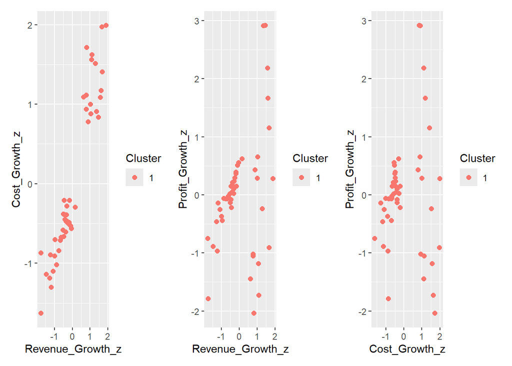

```r
km_k1 <- fit_kmeans(1)
pairwise_scatter(km_k1)
```

```r
cluster_profile(km_k1)
```

```
# A tibble: 1 × 5
  cluster Revenue_Growth Cost_Growth Profit_Growth     n
    <int>          <dbl>       <dbl>         <dbl> <int>
1       1         0.0765      0.0902        0.0114    49
```

## $K=2$

Task: Repeat for two clusters.

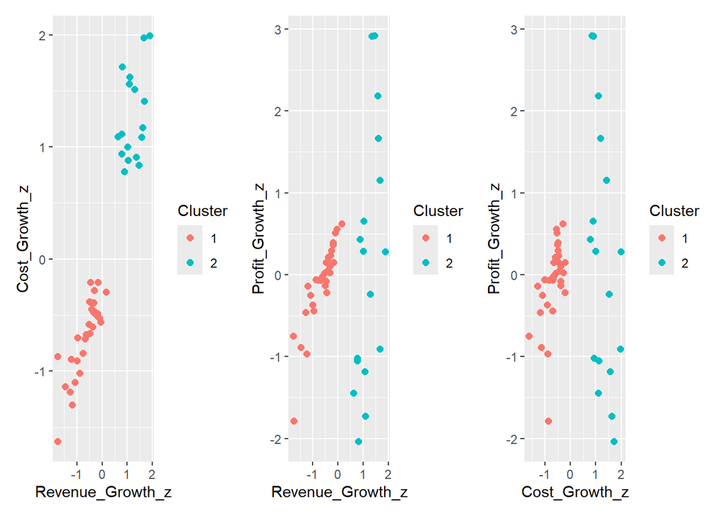

```r
km_k2 <- fit_kmeans(2)
pairwise_scatter(km_k2)
```

```r
cluster_profile(km_k2)
```

```
# A tibble: 2 × 5
  cluster Revenue_Growth Cost_Growth Profit_Growth     n
    <int>          <dbl>       <dbl>         <dbl> <int>
1       1        0.00148     0.00367      -0.00947    32
2       2        0.218       0.253         0.0506     17
```

## $K=3$

Task: Repeat for three clusters.

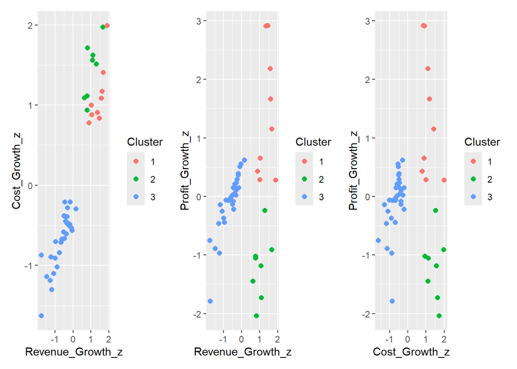

```r
km_k3 <- fit_kmeans(3)
pairwise_scatter(km_k3)
```

```r
cluster_profile(km_k3)
```

```
# A tibble: 3 × 5
  cluster Revenue_Growth Cost_Growth Profit_Growth     n
    <int>          <dbl>       <dbl>         <dbl> <int>
1       3        0.00148     0.00367      -0.00947    32
2       2        0.195       0.275        -0.265       8
3       1        0.238       0.234         0.331       9
```

## $K=4$

Task: Repeat for four clusters.

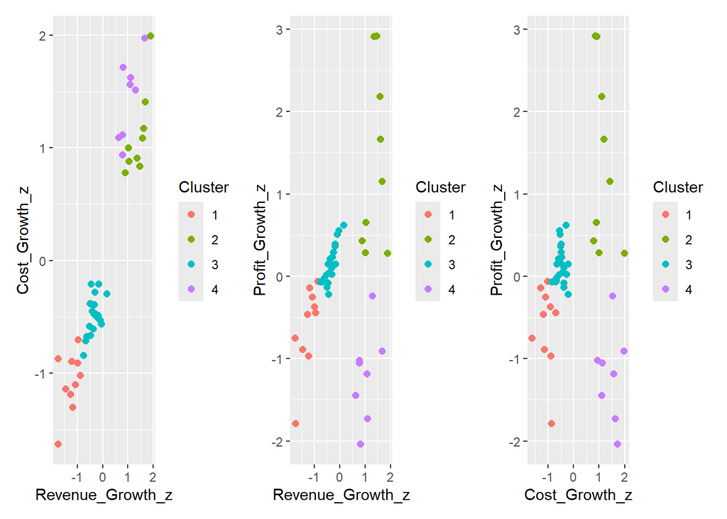

```r
km_k4 <- fit_kmeans(4)
pairwise_scatter(km_k4)
```

```r
cluster_profile(km_k4)
```

```
# A tibble: 4 × 5
  cluster Revenue_Growth Cost_Growth Profit_Growth     n
    <int>          <dbl>       <dbl>         <dbl> <int>
1       1        -0.0705     -0.0475       -0.129     10
2       3         0.0342      0.0269        0.0448    22
3       4         0.195       0.275        -0.265      8
4       2         0.238       0.234         0.331      9
```

Numeric cluster labels cannot be tracked meaningfully across different values of $K$. Instead, track both the assignment and the centroid profile attached to that assignment.

```r
membership_with_centroid <- function(fit, k_label) {
  centers <- fit$centers %>%
    as.data.frame() %>%
    tibble::rownames_to_column("cluster") %>%
    mutate(cluster = as.integer(cluster)) %>%
    as_tibble()

  tibble(
    Industry = growth_features$Industry,
    cluster = fit$cluster
  ) %>%
    left_join(centers, by = "cluster") %>%
    mutate(K = k_label, .before = Industry)
}

tracked_industries <- bind_rows(
  membership_with_centroid(km_k1, "K = 1"),
  membership_with_centroid(km_k2, "K = 2"),
  membership_with_centroid(km_k3, "K = 3"),
  membership_with_centroid(km_k4, "K = 4")
) %>%
  filter(Industry %in% c("Industry01", "Industry44")) %>%
  arrange(Industry, K)

tracked_industries
```

```
# A tibble: 8 × 6
  K     Industry   cluster Revenue_Growth_z Cost_Growth_z Profit_Growth_z
  <chr> <chr>        <int>            <dbl>         <dbl>           <dbl>
1 K = 1 Industry01       1         9.06e-18      4.30e-17       -2.27e-17
2 K = 2 Industry01       1        -6.44e- 1     -6.75e- 1       -9.05e- 2
3 K = 3 Industry01       3        -6.44e- 1     -6.75e- 1       -9.05e- 2
4 K = 4 Industry01       1        -1.26e+ 0     -1.07e+ 0       -6.10e- 1
5 K = 1 Industry44       1         9.06e-18      4.30e-17       -2.27e-17
6 K = 2 Industry44       1        -6.44e- 1     -6.75e- 1       -9.05e- 2
7 K = 3 Industry44       3        -6.44e- 1     -6.75e- 1       -9.05e- 2
8 K = 4 Industry44       3        -3.63e- 1     -4.94e- 1        1.45e- 1
```

Q: What happens as $K$ increases?

A:

- At $K=1$, all observations share one centroid.
- Increasing $K$ gives the algorithm more centroids and therefore weakly lowers total within-cluster sum of squares.
- In this simulation, the profile tables indicate that $K=2$ separates a broadly flat-growth group from a high-growth group; $K=3$ separates the high-growth industries by their Profit Growth behavior; and $K=4$ further subdivides one of the broader regimes.
- K-means solutions are not hierarchical. Although the clusters may appear to split neatly in this dataset, moving from $K$ to $K+1$ can reorganize several clusters rather than simply dividing one existing cluster.
- More clusters create more detailed segments, but eventually the extra detail may represent noise, unstable boundaries, or groups too small to support a separate business policy.

# Choosing $K$

No single diagnostic mechanically determines the economically “correct” number of clusters. We combine statistical evidence with interpretability, stability, and the intended decision use.

## Elbow Method

The elbow method examines how quickly total within-cluster sum of squares falls as $K$ increases. We look for a point after which additional clusters provide much smaller improvements.

Task: Construct an elbow plot for $K=1,\ldots,10$.

```r
wss <- purrr::map_dbl(1:10, function(k) {
  fit_kmeans(k, seed = 4821, nstart = 20)$tot.withinss
})

elbow_df <- tibble(
  k = 1:10,
  wss = wss
) %>%
  mutate(
    reduction = lag(wss) - wss,
    proportional_reduction = reduction / lag(wss)
  )

elbow_df
```

```
# A tibble: 10 × 4
       k    wss reduction proportional_reduction
   <int>  <dbl>     <dbl>                  <dbl>
 1     1 144       NA                     NA
 2     2  63.0     81.0                    0.562
 3     3  33.6     29.4                    0.467
 4     4  21.8     11.8                    0.350
 5     5  13.4      8.41                   0.385
 6     6  11.0      2.38                   0.177
 7     7   9.08     1.96                   0.178
 8     8   7.79     1.29                   0.142
 9     9   6.21     1.58                   0.203
10    10   5.58     0.635                  0.102
```

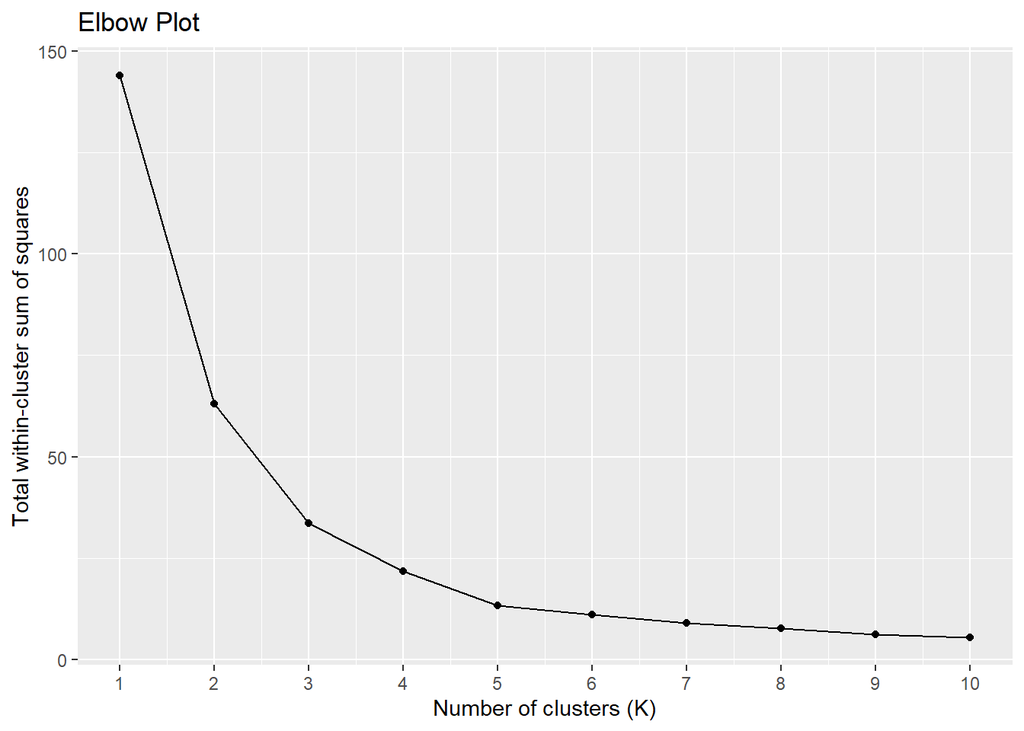

```r
ggplot(elbow_df, aes(k, wss)) +
  geom_line() +
  geom_point() +
  scale_x_continuous(breaks = 1:10) +
  labs(
    title = "Elbow Plot",
    x = "Number of clusters (K)",
    y = "Total within-cluster sum of squares"
  )
```

Q: How many clusters does the elbow plot suggest?

A: The elbow is not sharp. $K=2$ and $K=3$ are both defensible, with the marginal improvement generally slowing after the first few clusters. This ambiguity is normal and is a reason to examine additional diagnostics.

## Gap Statistic

The gap statistic compares the observed within-cluster dispersion with dispersion expected from reference datasets that contain no comparable cluster structure.

From the gap plot, we look for the first K where the gap curve “levels off”.

For a more rigorous approach, we can follow the Tibs2001SEMax rule: Choose the smallest K for which adding another cluster doesn’t improve the Gap statistic by more than one standard error.

Task: Construct a gap-statistic plot for $K=1,\ldots,10$.

```r
set.seed(4821)
gap_stat <- cluster::clusGap(
  X_growth,
  FUNcluster = function(x, k) {
    kmeans(x, centers = k, nstart = 20)
  },
  K.max = 10,
  B = 100
)

gap_df <- gap_stat$Tab %>%
  as.data.frame() %>%
  tibble::rownames_to_column("k") %>%
  as_tibble() %>%
  mutate(k = as.integer(k))

gap_k <- cluster::maxSE(
  gap_stat$Tab[, "gap"],
  gap_stat$Tab[, "SE.sim"],
  method = "Tibs2001SEmax"
)

gap_df
```

```
# A tibble: 10 × 5
       k  logW E.logW   gap SE.sim
   <int> <dbl>  <dbl> <dbl>  <dbl>
 1     1  3.21   3.46 0.248 0.0498
 2     2  2.72   3.14 0.427 0.0497
 3     3  2.45   2.89 0.431 0.0446
 4     4  2.19   2.68 0.497 0.0475
 5     5  2.00   2.54 0.541 0.0488
 6     6  1.88   2.41 0.525 0.0497
 7     7  1.80   2.30 0.494 0.0482
 8     8  1.67   2.19 0.524 0.0482
 9     9  1.61   2.10 0.490 0.0499
10    10  1.46   2.01 0.547 0.0549
```

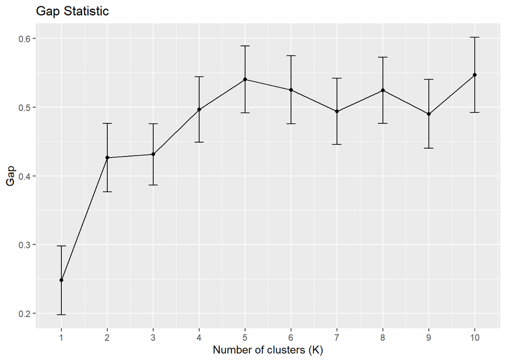

```r
ggplot(gap_df, aes(k, gap)) +
  geom_line() +
  geom_point() +
  geom_errorbar(
    aes(ymin = gap - SE.sim, ymax = gap + SE.sim),
    width = 0.2
  ) +
  scale_x_continuous(breaks = 1:10) +
  labs(
    title = "Gap Statistic",
    x = "Number of clusters (K)",
    y = "Gap"
  )
```

```r
gap_k
```

```
[1] 2
```

Q: How many clusters does the gap statistic suggest?

A: Using the `Tibs2001SEmax` rule, the gap statistic suggests $K=$ 2.

## Silhouette Width

For each observation, silhouette width compares cohesion with its assigned cluster against separation from the nearest alternative cluster. Values near 1 indicate strong assignment, values near 0 indicate a boundary observation, and negative values suggest possible misassignment.

Task: Compute average silhouette width for $K=2,\ldots,10$.

```r
growth_distance <- dist(X_growth)

silhouette_scores <- purrr::map_dfr(2:10, function(k) {
  fit <- fit_kmeans(k, seed = 4821, nstart = 20)
  sil <- cluster::silhouette(fit$cluster, growth_distance)

  tibble(
    k = k,
    average_silhouette_width = mean(sil[, "sil_width"])
  )
})

silhouette_k <- silhouette_scores %>%
  slice_max(average_silhouette_width, n = 1, with_ties = FALSE) %>%
  pull(k)

silhouette_scores
```

```
# A tibble: 9 × 2
      k average_silhouette_width
  <int>                    <dbl>
1     2                    0.588
2     3                    0.629
3     4                    0.536
4     5                    0.540
5     6                    0.468
6     7                    0.455
7     8                    0.403
8     9                    0.414
9    10                    0.396
```

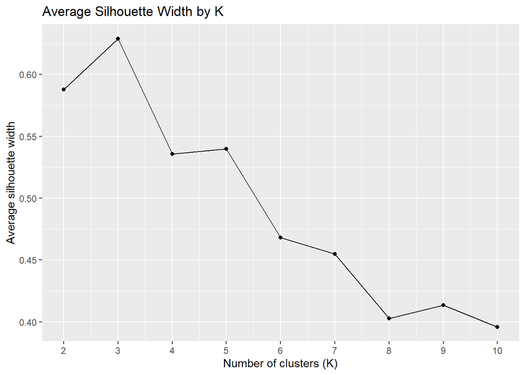

```r
ggplot(
  silhouette_scores,
  aes(k, average_silhouette_width)
) +
  geom_line() +
  geom_point() +
  scale_x_continuous(breaks = 2:10) +
  labs(
    title = "Average Silhouette Width by K",
    x = "Number of clusters (K)",
    y = "Average silhouette width"
  )
```

```r
silhouette_k
```

```
[1] 3
```

Task: Inspect the detailed silhouette plot for the best-scoring $K$.

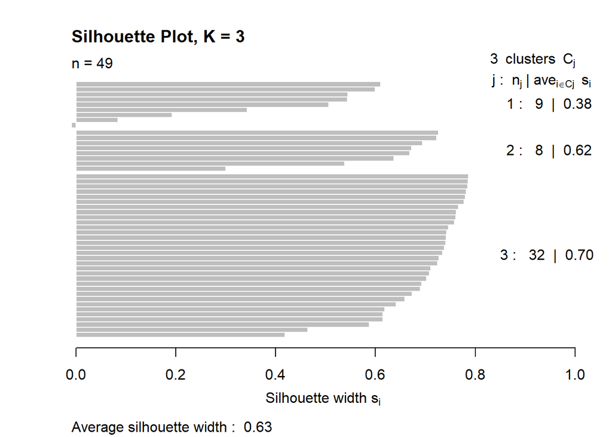

```r
km_silhouette_best <- fit_kmeans(
  silhouette_k,
  seed = 4821,
  nstart = 20
)

silhouette_best <- cluster::silhouette(
  km_silhouette_best$cluster,
  growth_distance
)

plot(
  silhouette_best,
  main = paste("Silhouette Plot, K =", silhouette_k)
)
```

Q: Which cluster appears most internally coherent and well separated from the other clusters?

A: Cluster 3. It contains 32 industries and has an average silhouette width of 0.70. Most of its observations have relatively large positive silhouette widths.

Q: Which cluster appears least clearly separated?

A: Cluster 1, with an average silhouette width of 0.38. It also contains an observation with a silhouette width near or below zero, suggesting that at least one industry lies near the boundary with another cluster.

Task: Fit K=4, inspect its silhouette plot.

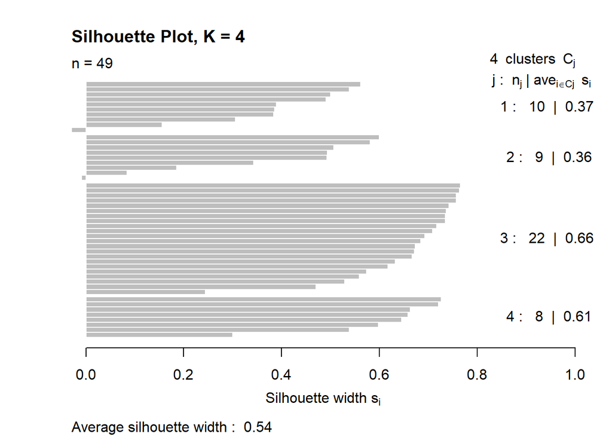

```r
km_silhouette_best <- fit_kmeans(
  4,
  seed = 4821,
  nstart = 20
)

silhouette_best <- cluster::silhouette(
  km_silhouette_best$cluster,
  growth_distance
)

plot(
  silhouette_best,
  main = paste("Silhouette Plot, K =", 4)
)
```

```r
km_3 <- fit_kmeans(3, seed = 4821, nstart = 20)
km_4 <- fit_kmeans(4, seed = 4821, nstart = 20)
```

Task: Create a cross-tabulation of the K=3 and K=4 assignments to determine how the original clusters were divided.

```r
table(
  K3 = km_3$cluster,
  K4 = km_4$cluster
)
```

```
   K4
K3   1  2  3  4
  1  0  9  0  0
  2  0  0  0  8
  3 10  0 22  0
```

Q: How read this cross tab? What’s the implication?

A:

- K=3, cluster 1 had 9 industries. Under K=4, all 9 remain together in cluster 2.
- K=3, cluster 2 had 8 industries. Under K=4, all 8 remain together in cluster 4.
- K=3, cluster 3 had 32 industries. Under K=4, it is split into:
  - 10 industries in K=4, cluster 1
  - 22 industries in K=4, cluster 3

Q: Does allowing K-means to form a fourth cluster improve the quality of the clustering?

A: No. The overall average silhouette width falls from approximately 0.63 for K=3 to 0.54 for K=4. Although K=4 creates an additional group and will necessarily reduce within-cluster sum of squares, the resulting clusters are, on average, less clearly separated from their nearest alternatives.

Q: Why can tot.withinss improve when moving from K=3 to K=4, while average silhouette width gets worse?

A: Adding another cluster gives K-means more flexibility to place observations closer to a centroid, so tot.withinss must weakly decrease. Silhouette width also considers how well each observation is separated from the nearest competing cluster. Splitting observations into more clusters can therefore improve within-cluster fit while making neighboring clusters less distinct.

Q: How many clusters does the silhouette analysis suggest?

A: Average silhouette width is maximized at $K=$ 3 over the candidate range.

## Synthesis

Task: Summarize the three diagnostics.

```r
selection_summary <- tibble(
  method = c("Elbow", "Gap statistic", "Silhouette"),
  suggested_k = c(
    "2 or 3; visually ambiguous",
    as.character(gap_k),
    as.character(silhouette_k)
  )
)

selection_summary
```

```
# A tibble: 3 × 2
  method        suggested_k
  <chr>         <chr>
1 Elbow         2 or 3; visually ambiguous
2 Gap statistic 2
3 Silhouette    3
```

Q: How many clusters should we use?

A: We will use $K=3$ for the remainder of the lesson. The elbow supports a small number of clusters, the silhouette evidence favors the best-separated candidate in this neighborhood, and the three-cluster solution has a useful economic interpretation: it separates a mature/flat regime from two high-growth regimes with different profit dynamics. A two-cluster solution remains a reasonable, more parsimonious alternative when the distinction between the two high-growth groups is not decision-relevant.

# Interpreting the Final Clusters

Cluster numbers are arbitrary. Economic names are assigned after reviewing the cluster profiles.

```r
chosen_k <- 3L

set.seed(4821)
km_final <- kmeans(
  X_growth,
  centers = chosen_k,
  nstart = 20
)

growth_clustered <- growth_rates_trim %>%
  mutate(cluster = km_final$cluster)

cluster_profiles <- growth_clustered %>%
  group_by(cluster) %>%
  summarise(
    Revenue_Growth = mean(Revenue_Growth),
    Cost_Growth = mean(Cost_Growth),
    Profit_Growth = mean(Profit_Growth),
    n = n(),
    .groups = "drop"
  ) %>%
  mutate(
    average_operating_growth = (Revenue_Growth + Cost_Growth) / 2
  )

flat_cluster <- cluster_profiles %>%
  slice_min(abs(average_operating_growth), n = 1, with_ties = FALSE) %>%
  pull(cluster)

high_growth_clusters <- setdiff(cluster_profiles$cluster, flat_cluster)

stronger_profit_cluster <- cluster_profiles %>%
  filter(cluster %in% high_growth_clusters) %>%
  slice_max(Profit_Growth, n = 1, with_ties = FALSE) %>%
  pull(cluster)

weaker_profit_cluster <- setdiff(
  high_growth_clusters,
  stronger_profit_cluster
)

cluster_name_map <- tibble(
  cluster = c(
    flat_cluster,
    stronger_profit_cluster,
    weaker_profit_cluster
  ),
  cluster_name = c(
    "Mature / flat growth",
    "High growth / stronger profit performance",
    "High growth / weaker profit performance"
  )
)

growth_clustered <- growth_clustered %>%
  left_join(cluster_name_map, by = "cluster")

cluster_profiles <- cluster_profiles %>%
  left_join(cluster_name_map, by = "cluster") %>%
  arrange(average_operating_growth)
```

Task: Display cluster sizes and average growth rates.

```r
cluster_profiles %>%
  select(
    cluster,
    cluster_name,
    n,
    Revenue_Growth,
    Cost_Growth,
    Profit_Growth
  )
```

```
# A tibble: 3 × 6
  cluster cluster_name                n Revenue_Growth Cost_Growth Profit_Growth
    <int> <chr>                   <int>          <dbl>       <dbl>         <dbl>
1       3 Mature / flat growth       32        0.00148     0.00367      -0.00947
2       2 High growth / weaker p…     8        0.195       0.275        -0.265
3       1 High growth / stronger…     9        0.238       0.234         0.331
```

Task: Visualize the clusters in the Revenue Growth–Cost Growth plane.

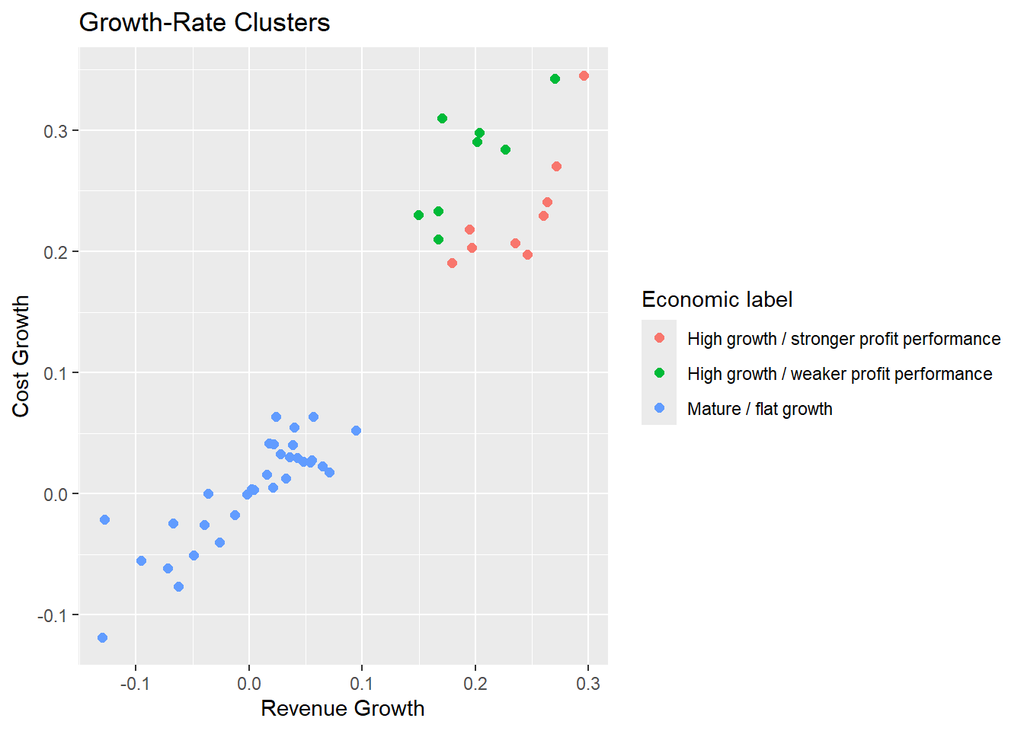

```r
ggplot(
  growth_clustered,
  aes(
    Revenue_Growth,
    Cost_Growth,
    color = cluster_name
  )
) +
  geom_point(size = 2) +
  labs(
    title = "Growth-Rate Clusters",
    x = "Revenue Growth",
    y = "Cost Growth",
    color = "Economic label"
  )
```

This is a two-dimensional view of a three-dimensional fit. Profit Growth still affects the assignments even though it is not displayed on the axes.

Task: Compare Year 1 Revenue and Operating Cost while retaining the growth-based cluster colors.

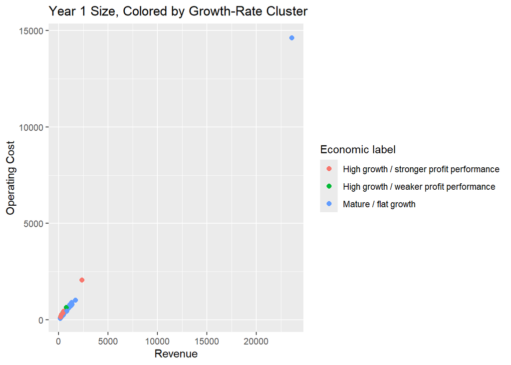

```r
level_view <- year1 %>%
  select(Industry, Revenue, Operating_Cost) %>%
  inner_join(
    growth_clustered %>%
      select(Industry, cluster, cluster_name),
    by = "Industry"
  )

ggplot(
  level_view,
  aes(
    Revenue,
    Operating_Cost,
    color = cluster_name
  )
) +
  geom_point(size = 2) +
  labs(
    title = "Year 1 Size, Colored by Growth-Rate Cluster",
    x = "Revenue",
    y = "Operating Cost",
    color = "Economic label"
  )
```

Task: Display cluster membership.

```r
growth_clustered %>%
  select(Industry, cluster, cluster_name) %>%
  arrange(cluster_name, Industry)
```

```
# A tibble: 49 × 3
   Industry   cluster cluster_name
   <chr>        <int> <chr>
 1 Industry10       1 High growth / stronger profit performance
 2 Industry17       1 High growth / stronger profit performance
 3 Industry35       1 High growth / stronger profit performance
 4 Industry42       1 High growth / stronger profit performance
 5 Industry43       1 High growth / stronger profit performance
 6 Industry45       1 High growth / stronger profit performance
 7 Industry47       1 High growth / stronger profit performance
 8 Industry48       1 High growth / stronger profit performance
 9 Industry50       1 High growth / stronger profit performance
10 Industry02       2 High growth / weaker profit performance
# ℹ 39 more rows
```

Q: What is the economic meaning of the final clusters?

A:

- The Mature / flat growth cluster contains industries with Revenue and Cost Growth near zero on average.
- The two high-growth clusters both have substantially higher Revenue and Cost Growth, but they differ in average Profit Growth. That distinction can be interpreted as differing profit or margin dynamics within otherwise fast-growing industries.
- The names are analyst-created summaries, not outputs supplied by `kmeans()`.
- `Industry32` remains in the growth analysis because it is unusual only in dollar size. The raw-level plot shows why a size outlier can still belong to an ordinary growth regime.
- `Industry07` remains excluded from the main growth fit and will be added back next to measure its influence.

# Sensitivity and Stability

## Outlier in Levels: Add `Industry32` Back

Task: Repeat the $K=2$ feature-redundancy comparison using the full, Year 1-standardized sample.

```r
set.seed(4821)
km_all3_full <- kmeans(
  year1_std_full %>% select(Revenue_z, Operating_Cost_z, Profit_z),
  centers = 2,
  nstart = 20
)

set.seed(4821)
km_2feat_full <- kmeans(
  year1_std_full %>% select(Revenue_z, Operating_Cost_z),
  centers = 2,
  nstart = 20
)

full_level_comparison <- year1_std_full %>%
  transmute(
    Industry,
    cluster_all3 = km_all3_full$cluster,
    cluster_2feat = km_2feat_full$cluster
  )

full_level_ari <- mclust::adjustedRandIndex(
  full_level_comparison$cluster_all3,
  full_level_comparison$cluster_2feat
)

table(
  All3 = full_level_comparison$cluster_all3,
  TwoFeat = full_level_comparison$cluster_2feat
)
```

```
    TwoFeat
All3  1  2
   1  1  0
   2  0 49
```

```r
full_level_comparison %>%
    dplyr::count(cluster_all3)
```

```
# A tibble: 2 × 2
  cluster_all3     n
         <int> <int>
1            1     1
2            2    49
```

```r
full_level_ari
```

```
[1] 1
```

Q: What changes once `Industry32` is added back?

A:

- The one observation in cluster 1 under the three-variable model is also in cluster 1 under the two-variable model.
- The other 49 observations are all in cluster 2 under both models.
- No observations switch clusters.
- The ARI=1, which means the two cluster assignments are exactly the same, ignoring arbitrary cluster labels.
- Adding Profit as a third feature does not change the K=2 partition at all. Both specifications isolate the same single industry from the other 49 industries.

## Outlier in Growth Rates: Add `Industry07` Back

Task: Repeat the $K=3$ growth clustering with all industries and compare the common observations with the trimmed result.

```r
X_growth_full <- growth_rates_std_full %>%
  select(Revenue_Growth_z, Cost_Growth_z, Profit_Growth_z) %>%
  as.matrix()

set.seed(4821)
km_full_k3 <- kmeans(
  X_growth_full,
  centers = 3,
  nstart = 20
)

full_growth_assignments <- tibble(
  Industry = growth_rates_std_full$Industry,
  cluster_full = km_full_k3$cluster
)

full_growth_profiles <- growth_rates %>%
  left_join(full_growth_assignments, by = "Industry") %>%
  group_by(cluster_full) %>%
  summarise(
    across(c(Revenue_Growth, Cost_Growth, Profit_Growth), mean),
    n = n(),
    .groups = "drop"
  )

compare_growth <- growth_clustered %>%
  select(Industry, cluster_trimmed = cluster) %>%
  left_join(full_growth_assignments, by = "Industry")

growth_outlier_ari <- mclust::adjustedRandIndex(
  compare_growth$cluster_trimmed,
  compare_growth$cluster_full
)

full_growth_profiles
```

```
# A tibble: 3 × 5
  cluster_full Revenue_Growth Cost_Growth Profit_Growth     n
         <int>          <dbl>       <dbl>         <dbl> <int>
1            1        0.00148     0.00367      -0.00947    32
2            2        0.218       0.253         0.0506     17
3            3        0.95        1.2          -3.80        1
```

```r
table(
  trimmed = compare_growth$cluster_trimmed,
  full = compare_growth$cluster_full
)
```

```
       full
trimmed  1  2
      1  0  9
      2  0  8
      3 32  0
```

```r
growth_outlier_ari
```

```
[1] 0.8779858
```

Q: What changes once `Industry07` is added back?

Q: How did adding the outlier affect the K=3 solution?

A: The outlier received a cluster of its own. Because the total number of clusters remained fixed at three, the algorithm then had only two clusters available for the other 49 industries. The original 32-industry cluster remained intact, while the original 9- and 8-industry clusters merged into a 17-industry cluster. The ARI of about 0.88 indicates that the two partitions remain broadly similar, but they are not identical.

## Starting Values and `nstart`

`nstart` repeats K-means from multiple random initial centroid sets and retains the fit with the smallest total within-cluster sum of squares.

Task: Compare `nstart = 1` and `nstart = 20` across 50 random seeds.

```r
initialization_results <- purrr::map_dfr(
  c(1L, 20L),
  function(number_of_starts) {
    purrr::map_dfr(1:50, function(seed_value) {
      set.seed(seed_value)

      fit <- kmeans(
        X_growth,
        centers = chosen_k,
        nstart = number_of_starts
      )

      tibble(
        nstart = number_of_starts,
        seed = seed_value,
        tot_withinss = fit$tot.withinss
      )
    })
  }
)

initialization_summary <- initialization_results %>%
  group_by(nstart) %>%
  summarise(
    minimum_wss = min(tot_withinss),
    median_wss = median(tot_withinss),
    maximum_wss = max(tot_withinss),
    distinct_objective_values = n_distinct(round(tot_withinss, 6)),
    .groups = "drop"
  )

initialization_summary
```

```
# A tibble: 2 × 5
  nstart minimum_wss median_wss maximum_wss distinct_objective_values
   <int>       <dbl>      <dbl>       <dbl>                     <int>
1      1        33.6       51.3        51.3                         3
2     20        33.6       33.6        33.6                         1
```

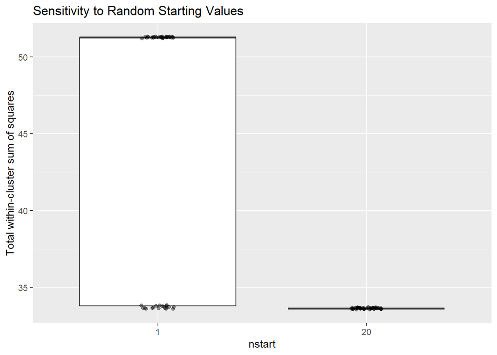

```r
ggplot(
  initialization_results,
  aes(factor(nstart), tot_withinss)
) +
  geom_boxplot() +
  geom_jitter(width = 0.08, alpha = 0.4) +
  labs(
    title = "Sensitivity to Random Starting Values",
    x = "nstart",
    y = "Total within-cluster sum of squares"
  )
```

```r
nstart_1_range <- initialization_summary %>%
  filter(nstart == 1) %>%
  transmute(range = maximum_wss - minimum_wss) %>%
  pull(range)

nstart_20_range <- initialization_summary %>%
  filter(nstart == 20) %>%
  transmute(range = maximum_wss - minimum_wss) %>%
  pull(range)
```

Q: What is the impact of `nstart` on the final result?

A:

- Across these seeds, the range of total within-cluster sum of squares is 17.642 for `nstart = 1` and 0 for `nstart = 20`.
- Variation under `nstart = 1` indicates sensitivity to random initial centroids and convergence to different local solutions.
- A larger `nstart` substantially reduces the risk of retaining a poor local solution because the best objective value is selected from many attempts.
- `nstart` does not mathematically guarantee the global optimum, but it is inexpensive insurance for a dataset of this size. Setting a seed makes the selected result reproducible.

# Implications for Financial Analysis

Q: How could a commercial bank use these clusters?

A:

- Lending policy and pricing: Design benchmark covenants, review intensity, and pricing ranges around broad operating regimes rather than creating an unrelated rule for every industry.
- Stress testing: Apply common revenue, cost, or margin shocks to industries with similar growth dynamics, while preserving industry-specific overlays where necessary.
- Exception handling: Treat influential observations such as `Industry07` or `Industry32` as candidates for individual review rather than allowing them to define a broad peer group unintentionally.
- Portfolio monitoring: Use changes in cluster profile or distance from a centroid as descriptive signals, but investigate the underlying financial drivers before changing a credit decision.
- Model validation: Test whether the clusters are stable over time and whether they actually differ in relevant downstream outcomes such as default, loss severity, covenant breaches, or rating migration. Clusters are descriptive until validated against the bank’s decision objective.